# Week 2: Data Driven Decision Making as a Process

# D<sup>3</sup>M

## Setting

People that run businesses, government, or other organizations are striving to reach some goal and need to adapt to changing conditions.

## Human judgement as a threat to sound decision-making

- Decisions—whether in business, government, or other fields—are often influenced by human judgment.
- Our intuition can be helpful, but it can also lead us astray.
- Recognizing the predictable errors in our thinking helps us make better use of data and avoid common pitfalls in decision-making.

## Cogitive or psychological biases

Predictable mental errors arise from our limited ability to process information objectively:

- **Confirmation bias**: Favoring information that aligns with our preconceptions.
  - *Example*: You believe that studying in the library is always more productive than at home, so you only pay attention to times when you were productive at the library, ignoring moments when studying at home was equally or more effective.
- **Anchoring**: Overemphasizing initial pieces of information when making decisions.
  - *Example*: While shopping for a car, you see a high sticker price on the first car and assume all cars in your budget are a good deal by comparison, even if they aren’t.
- **Gambler’s fallacy**: Believing that past events influence future probabilities in situations where they do not.
  - *Example*: You’re flipping a coin, and it lands on heads five times in a row. You assume the next flip *must* be tails, even though the probability remains 50/50.

Strong positive or negative emotions can also significantly influence decisions (Bucurean, 2018).

As humans, we are inherently susceptible to these emotional and psychological biases.

## Data analysis as part of the solution

Instead of relying solely on experience or gut instinct, businesses can use careful data analysis to help guide their decisions.

- Objective data analysis is less susceptible to psychological biases.
- However, data analysis alone is rarely the solution—it serves as evidence to support the decision-making process.

## The Idea

The premise of this class is to build **evidence-based decisions** using D<sup>3</sup>M.

Data and analysis are important tools that complement—rather than replace—intuition and experience.

By integrating data with our judgment, we can make more informed and balanced decisions!

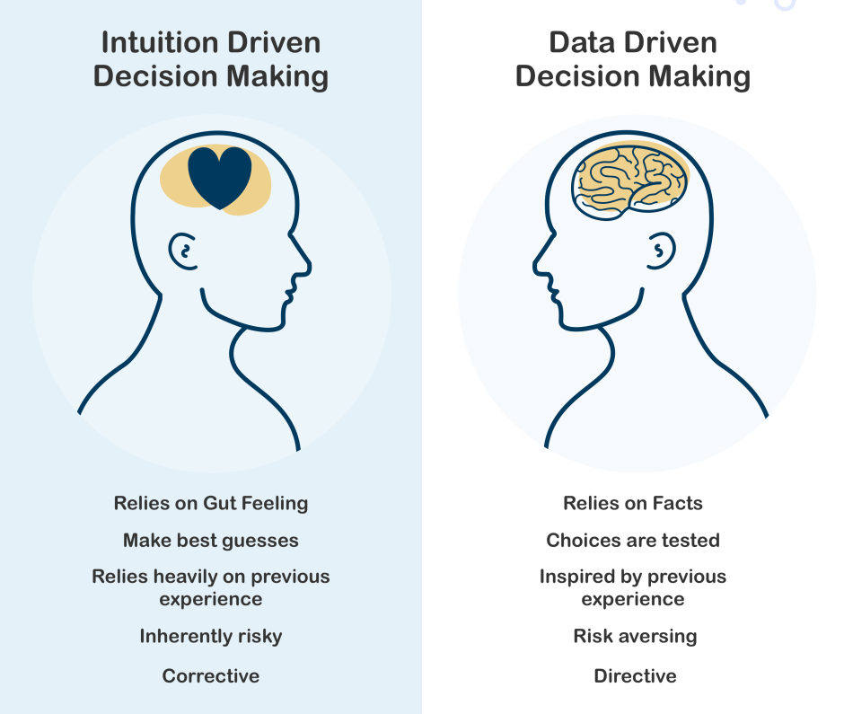

Source: https://blog.happyfox.com/data-driven-decision-making-using-data-to-fuel-growth/

## Example: Addressing food deserts

### Setting

A local government wants to improve food access in underserved communities. They aim to identify food deserts—areas with limited access to affordable and nutritious food—and determine where to establish new grocery stores or other interventions.

### Data analysis as part of the solution

To identify food deserts, the government gathers and analyzes data such as:

- **Demographics**: Income levels, population density, and household characteristics.
- **Geography**: Proximity of neighborhoods to existing grocery stores.
- **Transportation**: Availability of public transit and average travel times.

The data is used to map food deserts and prioritize areas based on need and potential impact.

### Cognitive biases can influence decision-making

Even with data, biases can affect decision-making:

- **Confirmation Bias**: Decision-makers may focus on areas they already perceive as food deserts, ignoring contrary evidence.
- **Anchoring**: Overemphasizing certain metrics, such as population density, while underestimating the importance of transit access.
- **Emotions**: Favoring high-profile neighborhoods for political or personal reasons.

### The Solution

By combining data analysis with an awareness of these biases, the government can:

- Identify areas with the greatest need for interventions.
- Develop targeted strategies that address root causes of food insecurity.
- Monitor and evaluate the impact of new grocery stores or transportation improvements to determine effectiveness.

# D<sup>3</sup>M is a process

## D<sup>3</sup>M process overview

Adapted from [source](https://www.smartsheet.com/data-driven-decision-making-management).

## 1. Define an objective

What is the business or operational question you are trying to answer?

- **Examples:**
  - Should we sell our product now or wait for a higher price?
  - Should we contract for feed or purchase on the spot market?

Clearly defining your objective provides focus and ensures your analysis aligns with the problem at hand.

## 2. Establish a hypothesis

A hypothesis is a proposed explanation or prediction based on your understanding of the system.

- What do you think the answer is, and why?
- Describe the mechanics of the system and explain your reasoning.

*Example:* “I hypothesize that contracting for feed reduces cost volatility compared to buying on the spot market because it locks in prices ahead of market fluctuations.”

## 3. Collect relevant data

Gather the information needed to answer your question:

- **Identify the data:** What specific data will help you answer your question? (e.g., historical prices, production costs, weather patterns)
- **Assemble the data:** Will you need equipment, surveys, or external databases?
- **Evaluate reliability:** Are your data sources accurate and unbiased?
- **Organize effectively:** Collect data in a format that can be analyzed—avoid unstructured formats…or sticky-notes :-)

## 4. Analyze the data

Design an analysis strategy to address your question:

- Choose an appropriate method (e.g., statistical analysis, cluster analysis, or regression analysis).
- Test different scenarios to explore potential outcomes.
- Identify variables or factors that can be changed to better achieve your objective.

*Example:* Simulate how feed price volatility impacts profit margins under different contract terms.

## 5. Interpret the results

- What do the results tell you about your original question?
- Identify actionable insights based on your findings.
- Reflect on whether the data supports your hypothesis or reveals something unexpected.

## 6. Communicate insights

Present your findings clearly and effectively:

- **Tell a story with data:** Use visuals to show the audience the impact of the current decision and how an alternative could improve outcomes.
- **Highlight benefits:** Clearly articulate how the proposed change adds value or reduces risk.

*Example:* A graph comparing profits with and without a feed contract can illustrate the stability achieved through contracting.

## 7. Implement, Evaluate, Restart

- **Implement:** Act on your recommendations and put the decision into practice.
- **Evaluate:** Monitor the outcomes to determine if the changes achieve the desired results.
- **Restart:** Refine your approach and revisit the process for continuous improvement.

This cycle ensures ongoing adaptation and decision-making based on data-driven insights.

## You Do It: D<sup>3</sup>M Activity

In Pairs: Choose a business or organization (real or imagined) related to agriculture or natural resources. Work through the following steps together, completing the handout as a guide:

**1. Define the Objective**

- What is the business or operational question the organization is trying to answer?
- Briefly describe the business and its context.

**2. Establish a Hypothesis**

- What do you think the answer is, and why?
- Describe the mechanics of the system and explain your reasoning.

**3. Collect Relevant Data**

- What data would you need to answer the question?
- Where would you find this data, and how would you collect it?

**4. Analyze, Interpret, and Communicate**

- How would you analyze the data to answer the question? (e.g., software, statistics, or methods).
- How would you communicate the findings? What visuals or tools would help?

**Submit your responses using iClicker.**

## Before Lab

Review [Lab Notes](https://csu-arec-330.github.io/materials/unit_00/week_02/lab_00_week_02.html) for week 2

Schedule your 15-minute 1-on-1 (if you haven’t already)

## References

Brynjolfsson, Erik, and Kristina McElheran. “The rapid adoption of data-driven decision-making.” American Economic Review 106.5 (2016): 133-39.

## Download Week 2 Slides

📥 Download as PDF